# Practice Machine Learning Project

LY

4/22/2021

### Background and Goal

Using devices such as Jawbone Up, Nike FuelBand, and Fitbit it is now possible to collect a large amount of data about personal activity relatively inexpensively. These type of devices are part of the quantified self movement – a group of enthusiasts who take measurements about themselves regularly to improve their health, to find patterns in their behavior, or because they are tech geeks. One thing that people regularly do is quantify how much of a particular activity they do, but they rarely quantify how well they do it. In this project, Six participants at age 20-28 were asked to perform one set of 10 repetitions of the Unilateral Dumbbell Biceps Curl in five different fashions: exactly according to the specification (Class A), throwing the elbows to the front (Class B), lifting the dumbbell only halfway (Class C), lowering the dumbbell only halfway (Class D) and throwing the hips to the front (Class E). More information is available from the website here: http://groupware.les.inf.puc-rio.br/har (see the section on the Weight Lifting Exercise Dataset).

The training data for this project are available here: https://d396qusza40orc.cloudfront.net/predmachlearn/pml-training.csv

The test data are available here: https://d396qusza40orc.cloudfront.net/predmachlearn/pml-testing.csv

The goal of this project is to predict the manner (the “classe” variable in the training set) in which the participants did the exercise using data from accelerometers on the belt, forearm, arm, and dumbell. The ‘classe’ variable can be predicted with any of the other variables. Modeling, validation and thoughts of expected out of sample error will be included in this report. The prediction model will be used to predict 20 different test cases.

### Implementation

First step is to load and clean the data.

```r
library(caret)
library(randomForest)
```

```r
library(rpart)
library(rpart.plot)
library(rattle)
### Read in the downloaded data and check the data
trainingData <- read.csv("pml-training.csv", header = TRUE, sep = ",", na.strings = c("NA", ""))
testingData <- read.csv("pml-testing.csv", header = TRUE, sep = ",", na.strings = c("NA", ""))

### Clean the data
## Clean data step 1: remove variables containing NA’s and missing values.
trainingData <- trainingData[, which(sapply(trainingData, function(x) {sum(is.na(x))}) == 0)]
testingData <- testingData[, which(sapply(testingData, function(x) {sum(is.na(x))}) == 0)]
dim(trainingData)
```

```
## [1] 19622    60
```

```r
## The variables have now been reduced from 160 to 60 in the data set.
## Clean data step 2: remove variables have near zero variance
nzv <- nearZeroVar(trainingData, saveMetrics = TRUE)
trainingData <- trainingData[ , nzv$nzv == "FALSE"]
trainingData$classe <- as.factor(trainingData$classe)
nzv <- nearZeroVar(testingData, saveMetrics = TRUE)
testingData <- testingData[ , nzv$nzv == "FALSE"]
dim(trainingData)
```

```
## [1] 19622    59
```

```r
## Clean data step 3: remove the first 6 variables, as they have nothing to do with making the predictions
## There were many observations of each variable (n = 19622). Because random forest processing can be quite time-consuming, I subsetted only 5000 rows for the classification to process more quickly.
set.seed(123)
trainingDataSubset <- trainingData[sample(nrow(trainingData), 5000), -c(1:6)]
testingData <- testingData[ , -c(1:6)]
dim(trainingDataSubset)
```

```
## [1] 5000   53
```

```r
## Split training data set into two parts
set.seed(1234)
inTrain <- createDataPartition(trainingDataSubset$classe, p = 0.7, list = FALSE)
training <- trainingDataSubset[inTrain, ]
testing <- trainingData[-inTrain, ]
```

Next step is to build the model using the method of Random Forest. The reason for this is that Random Forest is very accurate among other algorithms and it runs very efficiently on large data sets. We will run the set on 5-fold cross validation. In 5-fold cross-validation, the original data-set is randomly partitioned into 5 equal sized sub data-sets. Of the 5 sub data-sets, a single sub data-set is retained as the validation data for testing the model, and the remaining 4 sub data-sets are used as training data. The cross-validation process is then repeated 5 times (the folds), with each of the 5 sub data-sets used exactly once as the validation data. The 5 results from the folds can then be averaged (or otherwise combined) to produce a single estimation.

```r
set.seed(12345)
rfModel <- train(classe ~., method = "rf", data = training,
                 trControl = trainControl(method = "cv", number = 5),
                 prox = TRUE, allowParallel = TRUE)

rfModel
```

```
## Random Forest
##
## 3501 samples
##   52 predictor
##    5 classes: 'A', 'B', 'C', 'D', 'E'
##
## No pre-processing
## Resampling: Cross-Validated (5 fold)
## Summary of sample sizes: 2801, 2801, 2800, 2801, 2801
## Resampling results across tuning parameters:
##
##   mtry  Accuracy   Kappa
##    2    0.9545849  0.9424288
##   27    0.9602975  0.9496925
##   52    0.9551575  0.9431759
##
## Accuracy was used to select the optimal model using the largest value.
## The final value used for the model was mtry = 27.
```

Check performance of model The model will be tested on the validation data (partition of the training data) and a confusion matrix will be used to check the accuracy of the prediction on the validation data.

```r
predictTesting <- predict(rfModel, testing)
confusionMatrix(testing$classe, predictTesting)
```

```
## Confusion Matrix and Statistics
##
##           Reference
## Prediction    A    B    C    D    E
##          A 2065    6    4    3    1
##          B  114 3598   73   12    0
##          C    0   65 3316   32    9
##          D    6    7   87 3110    6
##          E    3   20   33   21 3530
##
## Overall Statistics
##
##                Accuracy : 0.9689
##                  95% CI : (0.9661, 0.9715)
##     No Information Rate : 0.2293
##     P-Value [Acc > NIR] : < 2.2e-16
##
##                   Kappa : 0.9608
##
##  Mcnemar's Test P-Value : < 2.2e-16
##
## Statistics by Class:
##
##                      Class: A Class: B Class: C Class: D Class: E
## Sensitivity            0.9438   0.9735   0.9439   0.9786   0.9955
## Specificity            0.9990   0.9840   0.9916   0.9918   0.9939
## Pos Pred Value         0.9933   0.9476   0.9690   0.9670   0.9787
## Neg Pred Value         0.9912   0.9920   0.9845   0.9947   0.9987
## Prevalence             0.1357   0.2293   0.2179   0.1971   0.2200
## Detection Rate         0.1281   0.2232   0.2057   0.1929   0.2190
## Detection Prevalence   0.1290   0.2355   0.2123   0.1995   0.2237
## Balanced Accuracy      0.9714   0.9787   0.9678   0.9852   0.9947
```

```r
##Accuracy
accuracy <- confusionMatrix(testing$classe, predictTesting)$overall[1]
##Out of sample error
OOSError <- 1 - confusionMatrix(testing$classe, predictTesting)$overall[1]
cat("Accuracy: ", accuracy)
```

```
## Accuracy:  0.9688605
```

```r
cat("Out of sample error: ", OOSError)
```

```
## Out of sample error:  0.03113951
```

Finally, run the model on the test data The Random Forest model is now applied to the test data to predict the outcome.

```r
answer <- predict(rfModel, testingData)
answer
```

```
##  [1] B A A A A E D D A A B C B A E E A B B B
## Levels: A B C D E
```

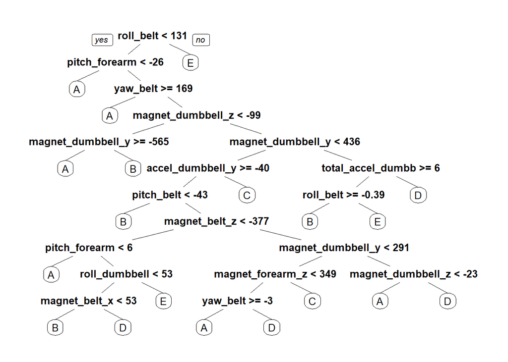

```r
##Random Forest decision tree
rfModelTree <- rpart(classe ~., data = training, method = "class")
prp(rfModelTree)
```

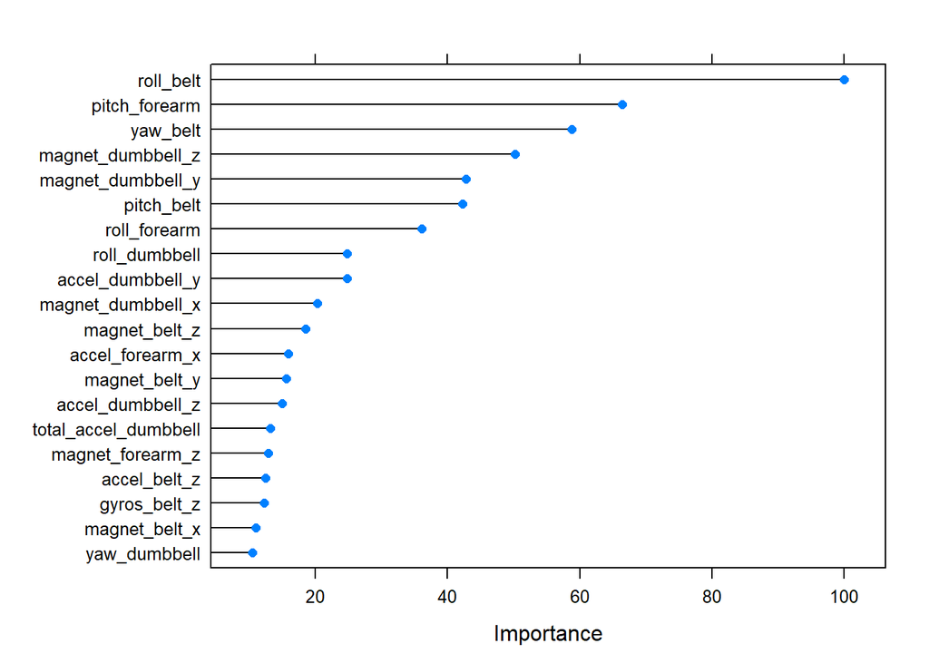

```r
##Plot of the top 20 variables impact on outcome
plot(varImp(rfModel), top = 20)
```